# Parquet to summary: cuplyr, DuckDB, dplyr and data.table

## Setup

### Machine and software

All numbers come from one machine: a 12th Gen Intel(R) Core(TM) i9-12900K with 24 logical CPUs and 31 GB of RAM, and a NVIDIA GeForce RTX 5070 with 12 GB of memory. The data directory is on `/dev/mapper/root` (device type `crypt`, file system `btrfs`). Versions: cuplyr 0.1.1.9000 (package code at commit a82772f, libcudf 25.12.00), DuckDB 2.0.0, dplyr 1.2.1, arrow 26.0.1, data.table 1.18.4, R 4.6.1. cuplyr is loaded from the checkout with `pkgload::load_all()`; nothing is installed.

### Provenance

The driver appends a row to `provenance.csv` for every step it runs: the benchmark code’s commit, whether `bench/` had uncommitted changes, the commit of the package code and whether it was modified, and the start and end of the step. The steps that take timings refuse to run with uncommitted changes in `bench/`. The 26 step runs whose data are in use ran between 2026-11-11 19:26 and 2026-11-12 02:41, from 2 benchmark commits, `1fb0124` for the gen, check, readers, time, first, probe steps and `9b9f87a` for the rowwise_check, rowwise, idle steps, and package commit a82772f; none of them ran with uncommitted changes, and every one ended ok. 15 earlier step runs of the same step and piece were replaced by a later run (marked in the table; the replaced timing rows are archived and not used). The timings are the 12 time steps (one size, table and cache each); 0 of them ran more than once, and 0 timing rows were superseded (`timings-superseded.csv` keeps any attempt that a re-run replaces).

| step | piece | started | minutes | benchmark commit | bench/ clean | package commit | package clean | in use |
| --- | --- | --- | --- | --- | --- | --- | --- | --- |
| gen |  | 11-11 19:26:34 | 0.0 | 1fb0124 | TRUE | a82772f | TRUE | yes |
| gen |  | 11-11 19:29:25 | 0.0 | 1fb0124 | TRUE | a82772f | TRUE | yes |
| check |  | 11-11 19:45:48 | 3.8 | 1fb0124 | TRUE | a82772f | TRUE | yes |
| rowwise_check | all wide all | 11-11 20:16:39 | 1.8 | 1fb0124 | TRUE | a82772f | TRUE | no: run again later |
| readers |  | 11-11 20:19:30 | 14.3 | 1fb0124 | TRUE | a82772f | TRUE | yes |
| time | 1e6 narrow warm | 11-11 20:34:52 | 2.7 | 1fb0124 | TRUE | a82772f | TRUE | yes |
| time | 1e6 narrow cold | 11-11 20:38:33 | 2.8 | 1fb0124 | TRUE | a82772f | TRUE | yes |
| time | 1e6 wide warm | 11-11 20:45:02 | 2.7 | 1fb0124 | TRUE | a82772f | TRUE | yes |
| time | 1e6 wide cold | 11-11 20:48:43 | 2.8 | 1fb0124 | TRUE | a82772f | TRUE | yes |
| time | 1e7 narrow warm | 11-11 20:52:33 | 3.6 | 1fb0124 | TRUE | a82772f | TRUE | yes |
| time | 1e7 narrow cold | 11-11 20:57:30 | 3.8 | 1fb0124 | TRUE | a82772f | TRUE | yes |
| time | 1e7 wide warm | 11-11 21:29:39 | 3.6 | 1fb0124 | TRUE | a82772f | TRUE | yes |
| time | 1e7 wide cold | 11-11 21:34:17 | 3.8 | 1fb0124 | TRUE | a82772f | TRUE | yes |
| time | 1e8 narrow warm | 11-11 21:39:05 | 12.2 | 1fb0124 | TRUE | a82772f | TRUE | yes |
| time | 1e8 narrow cold | 11-11 21:52:16 | 12.4 | 1fb0124 | TRUE | a82772f | TRUE | yes |
| time | 1e8 wide warm | 11-11 22:05:42 | 12.4 | 1fb0124 | TRUE | a82772f | TRUE | yes |
| time | 1e8 wide cold | 11-11 22:19:10 | 12.9 | 1fb0124 | TRUE | a82772f | TRUE | yes |
| rowwise | 1e5 wide warm | 11-11 22:33:06 | 8.1 | 1fb0124 | TRUE | a82772f | TRUE | no: run again later |
| rowwise | 1e5 wide cold | 11-11 22:42:14 | 8.0 | 1fb0124 | TRUE | a82772f | TRUE | no: run again later |
| rowwise | 1e6 wide warm | 11-11 22:51:15 | 2.4 | 1fb0124 | TRUE | a82772f | TRUE | no: run again later |
| rowwise | 1e6 wide cold | 11-11 22:54:42 | 2.4 | 1fb0124 | TRUE | a82772f | TRUE | no: run again later |
| rowwise | 1e7 wide warm | 11-11 22:58:09 | 0.4 | 1fb0124 | TRUE | a82772f | TRUE | no: run again later |
| rowwise | 1e7 wide cold | 11-11 22:59:33 | 0.4 | 1fb0124 | TRUE | a82772f | TRUE | no: run again later |
| first |  | 11-11 23:00:57 | 1.5 | 1fb0124 | TRUE | a82772f | TRUE | yes |
| probe |  | 11-11 23:03:26 | 2.4 | 1fb0124 | TRUE | a82772f | TRUE | yes |
| rowwise_check | all wide all | 11-12 01:05:08 | 1.8 | b674eaa | TRUE | a82772f | TRUE | no: run again later |
| rowwise | 1e5 wide warm | 11-12 01:07:59 | 8.2 | b674eaa | TRUE | a82772f | TRUE | no: run again later |
| rowwise | 1e5 wide cold | 11-12 01:17:14 | 8.0 | b674eaa | TRUE | a82772f | TRUE | no: run again later |
| rowwise | 1e6 wide warm | 11-12 01:26:17 | 2.4 | b674eaa | TRUE | a82772f | TRUE | no: run again later |
| rowwise | 1e6 wide cold | 11-12 01:29:46 | 2.5 | b674eaa | TRUE | a82772f | TRUE | no: run again later |
| rowwise | 1e7 wide warm | 11-12 01:33:15 | 0.4 | b674eaa | TRUE | a82772f | TRUE | no: run again later |
| rowwise | 1e7 wide cold | 11-12 01:34:38 | 0.4 | b674eaa | TRUE | a82772f | TRUE | no: run again later |
| idle | 1e5 wide warm | 11-12 01:36:03 | 14.3 | b674eaa | TRUE | a82772f | TRUE | no: run again later |
| rowwise_check | all wide all | 11-12 01:55:50 | 1.8 | 9b9f87a | TRUE | a82772f | TRUE | yes |
| rowwise | 1e5 wide warm | 11-12 01:58:40 | 8.2 | 9b9f87a | TRUE | a82772f | TRUE | yes |
| rowwise | 1e5 wide cold | 11-12 02:07:51 | 8.2 | 9b9f87a | TRUE | a82772f | TRUE | yes |
| rowwise | 1e6 wide warm | 11-12 02:17:07 | 2.4 | 9b9f87a | TRUE | a82772f | TRUE | yes |
| rowwise | 1e6 wide cold | 11-12 02:20:35 | 2.5 | 9b9f87a | TRUE | a82772f | TRUE | yes |
| rowwise | 1e7 wide warm | 11-12 02:24:04 | 0.4 | 9b9f87a | TRUE | a82772f | TRUE | yes |
| rowwise | 1e7 wide cold | 11-12 02:25:28 | 0.4 | 9b9f87a | TRUE | a82772f | TRUE | yes |
| idle | 1e5 wide warm | 11-12 02:26:52 | 14.3 | 9b9f87a | TRUE | a82772f | TRUE | yes |

### Data

The data are synthetic and seeded, written once with arrow (`ParquetFileWriter`, snappy compression: the codec in `files.csv` is snappy, row groups of 1,048,576 rows, the last one shorter). The narrow table has 8 columns: `day` (a Date, sorted ascending, like an event log), `store`, `product` and `qty` (integers), `price` and `discount` (doubles; `discount` has missing values), `channel` and `category` (strings). The wide table has the same columns with identical values plus the filler columns `x01` to `x32` (integers and doubles with few distinct values), 40 columns in all; a pipeline reads at most 6 of them. A dimension file `stores.parquet` maps `store` to `region`. The rowwise pipeline (see its section) also reads the wide table at 1e5 rows, a file the main pipelines do not use, written by the same generator with the same seed.

| table | rows | size in MB | row groups | codec | columns |
| --- | --- | --- | --- | --- | --- |
| narrow | 1e6 | 8 | 1 | SNAPPY | 8 |
| narrow | 1e7 | 77 | 10 | SNAPPY | 8 |
| narrow | 1e8 | 773 | 96 | SNAPPY | 8 |
| wide | 1e5 | 4 | 1 | SNAPPY | 40 |
| wide | 1e6 | 36 | 1 | SNAPPY | 40 |
| wide | 1e7 | 359 | 10 | SNAPPY | 40 |
| wide | 1e8 | 3,593 | 96 | SNAPPY | 40 |

### Pipelines

Three pipelines, each with two filters, make six variants (`p1_push`, `p1_nopush`, and so on).

- `p1`: filter, mutate, group by store and channel, summarise (4000 groups)
- `p2`: filter, mutate, join to the store dimension, group by region and channel, summarise (40 groups)
- `p3`: filter, mutate, group by product, sum the revenue, keep the top 10 (ties kept)

The **push** filter is on the Date and the integer column (`day` on or after 2024-01-01 and `qty` at least 2). cuplyr moves such filters into the parquet scan (they are pushed), so row groups whose statistics rule them out are never read. The **nopush** filter is on the double and the string column (`price` at least 150 and `channel` not phone); cuplyr never pushes those. The two keep a similar share of the rows (19% and 19%), but they are not the same amount of work for an engine, and the CPU engines show it (see the pushdown section). Because `day` is sorted, the pushed date filter can skip whole row groups; how many row groups each pushed filter really skipped is in the pushdown table below.

### Engines and their code

Each engine is written the way its users write it, and reads only the columns the variant needs.

**cuplyr** reads with `read_parquet_gpu()`, which is lazy by default: the projection and the pushed filter go into the scan. The verbs build a plan (the function below). For the first and second pipelines the final `summarise()` runs the plan at the moment it is called, because `max()` of an integer column has a result type that depends on the data (F07), and `collect()` then only transfers the result to R; for the third pipeline `collect()` runs the plan (48 of cuplyr’s 72 cells are of the first two kinds). The option `cuplyr.fallback = "error"` makes a CPU fallback an error, so every number is a GPU number: 0 of cuplyr’s 793 calls in `timings.csv` ended with an error.

```r
function(variant, fact, dim) {
  k <- pp_constants()
  day_from <- k$day_from; qty_min <- k$qty_min
  price_min <- k$price_min; channel_drop <- k$channel_drop; topn <- k$top_n
  x <- cuplyr::read_parquet_gpu(fact)
  x <- if (grepl("_push$", variant)) {
    dplyr::filter(x, day >= day_from, qty >= qty_min)
  } else {
    dplyr::filter(x, price >= price_min, channel != channel_drop)
  }
  x <- dplyr::mutate(x, revenue = price * qty * (1 - discount))
  switch(pp_pipeline_of(variant),
    p1 = x |>
      dplyr::group_by(store, channel) |>
      dplyr::summarise(n = dplyr::n(), revenue = sum(revenue, na.rm = TRUE),
                       avg_price = mean(price), max_qty = max(qty), .groups = "drop"),
    p2 = x |>
      dplyr::inner_join(cuplyr::read_parquet_gpu(dim), by = "store") |>
      dplyr::group_by(region, channel) |>
      dplyr::summarise(n = dplyr::n(), revenue = sum(revenue, na.rm = TRUE),
                       avg_price = mean(price), max_qty = max(qty), .groups = "drop"),
    p3 = x |>
      dplyr::group_by(product) |>
      dplyr::summarise(revenue = sum(revenue, na.rm = TRUE), n = dplyr::n()) |>
      dplyr::slice_max(revenue, n = topn)
  )
}
```

**DuckDB** keeps one in-memory connection per process (`duckdb(shared_home = FALSE)`), opened before timing like a package load. The query is SQL over `read_parquet('<path>')` with explicit columns, fetched with `dbGetQuery()`. It is SQL rather than dbplyr or duckplyr because that is what a DuckDB user writes. Three of the six queries:

```sql
SELECT store, channel, count(*) AS n, coalesce(sum(price * qty * (1 - discount)), 0) AS revenue, avg(price) AS avg_price, max(qty) AS max_qty
FROM read_parquet('<fact>.parquet')
WHERE day >= DATE '2024-01-01' AND qty >= 2
GROUP BY store, channel
```

```sql
SELECT s.region AS region, f.channel AS channel, count(*) AS n, coalesce(sum(price * qty * (1 - discount)), 0) AS revenue, avg(price) AS avg_price, max(qty) AS max_qty
FROM read_parquet('<fact>.parquet') AS f JOIN read_parquet('<stores>.parquet') AS s ON f.store = s.store
WHERE price >= 150 AND channel <> 'phone'
GROUP BY s.region, f.channel
```

```sql
SELECT product, coalesce(sum(price * qty * (1 - discount)), 0) AS revenue, count(*) AS n
FROM read_parquet('<fact>.parquet')
WHERE day >= DATE '2024-01-01' AND qty >= 2
GROUP BY product
QUALIFY rank() OVER (ORDER BY revenue DESC) <= 10
```

**dplyr** reads with `arrow::read_parquet(path, col_select = cols)` and runs the same verbs on the tibble.

```r
function(variant, fact, dim) {
  k <- pp_constants()
  day_from <- k$day_from; qty_min <- k$qty_min
  price_min <- k$price_min; channel_drop <- k$channel_drop; topn <- k$top_n
  x <- pp_read_arrow(fact, pp_columns(variant))
  x <- if (grepl("_push$", variant)) {
    dplyr::filter(x, day >= day_from, qty >= qty_min)
  } else {
    dplyr::filter(x, price >= price_min, channel != channel_drop)
  }
  x <- dplyr::mutate(x, revenue = price * qty * (1 - discount))
  switch(pp_pipeline_of(variant),
    p1 = x |>
      dplyr::group_by(store, channel) |>
      dplyr::summarise(n = dplyr::n(), revenue = sum(revenue, na.rm = TRUE),
                       avg_price = mean(price), max_qty = max(qty), .groups = "drop"),
    p2 = x |>
      dplyr::inner_join(pp_read_arrow(dim, c("store", "region")), by = "store") |>
      dplyr::group_by(region, channel) |>
      dplyr::summarise(n = dplyr::n(), revenue = sum(revenue, na.rm = TRUE),
                       avg_price = mean(price), max_qty = max(qty), .groups = "drop"),
    p3 = x |>
      dplyr::group_by(product) |>
      dplyr::summarise(revenue = sum(revenue, na.rm = TRUE), n = dplyr::n()) |>
      dplyr::slice_max(revenue, n = topn)
  )
}
```

**data.table** uses the same reader, then `setDT()` and data.table syntax. Two idioms were timed on one variant of each pipeline, in every table and size (forms.csv): a single call (the filter in `i`, the arithmetic inside `j`) and a stepwise form (filter, then `:=`, then aggregate). The single call was faster in 3 of 18 cells; the benchmark uses the stepwise form. The join pipeline joins the filtered facts to the dimension first (a keyed `data.table` join), so its result is a new table either way: in its 6 cells the stepwise time is 0.97 to 1 times the single-call time (the stepwise form was faster in 4), so the choice hardly matters there.

```r
function(variant, fact, dim, form = pp_constants()$dt_form) {
  k <- pp_constants()
  day_from <- k$day_from; qty_min <- k$qty_min
  price_min <- k$price_min; channel_drop <- k$channel_drop; topn <- k$top_n
  DT <- data.table::setDT(pp_read_arrow(fact, pp_columns(variant)))
  keep <- if (grepl("_push$", variant)) {
    DT$day >= day_from & DT$qty >= qty_min
  } else {
    DT$price >= price_min & DT$channel != channel_drop
  }
  pipe <- pp_pipeline_of(variant)
  by <- switch(pipe, p1 = c("store", "channel"), p2 = c("region", "channel"), p3 = "product")
  joined <- NULL
  if (pipe == "p2") {
    stores <- data.table::setDT(pp_read_arrow(dim, c("store", "region")))
    joined <- stores[DT[keep], on = "store", nomatch = NULL]
  }
  if (form == "single") {
    res <- if (pipe == "p2") {
      joined[, .(n = .N, revenue = sum(price * qty * (1 - discount), na.rm = TRUE),
                 avg_price = mean(price), max_qty = max(qty)), by = by]
    } else if (pipe == "p3") {
      DT[keep, .(revenue = sum(price * qty * (1 - discount), na.rm = TRUE), n = .N), by = by]
    } else {
      DT[keep, .(n = .N, revenue = sum(price * qty * (1 - discount), na.rm = TRUE),
                 avg_price = mean(price), max_qty = max(qty)), by = by]
    }
  } else {
    x <- if (pipe == "p2") joined else DT[keep]
    x[, revenue := price * qty * (1 - discount)]
    res <- if (pipe == "p3") {
      x[, .(revenue = sum(revenue, na.rm = TRUE), n = .N), by = by]
    } else {
      x[, .(n = .N, revenue = sum(revenue, na.rm = TRUE),
            avg_price = mean(price), max_qty = max(qty)), by = by]
    }
  }
  if (pipe == "p3") res <- res[data.table::frank(-revenue, ties.method = "min") <= topn]
  res
}
```

None of the results is sorted inside the timed region (dplyr’s `summarise()` sorts, DuckDB does not); the comparison sorts them.

### Threads and other settings

Every engine runs at its default thread count, read back from the running engine: DuckDB runs 24 threads, arrow 24 CPU and 8 I/O threads (dplyr and data.table both read with it), data.table 12 threads, and cuplyr runs the query on the GPU (1 device). That does not make cuplyr’s process idle on the CPU: its own CPU time (user and system, all threads) is a share of all 24 logical CPUs; multiplied by 24 it is 1 core at the median over its timed calls and 2 cores at the median for 1e8 rows with a warm cache (the highest single call: 2.6 cores). The medians for the other engines over all their timed calls are duckdb 2.3 cores, dplyr 1.1 cores and data.table 1.4 cores. What the CPU time is spent on in cuplyr is not examined here.

The settings that bear on what a timing means were read back from the running engines into `threads.csv` (the machine and version rows are in the text above):

| engine | setting | value | step |
| --- | --- | --- | --- |
| cuplyr | gpu_devices | 1 | time |
| cuplyr | debug_stream_pool | set (1) | time |
| duckdb | threads | 24 | time |
| duckdb | cache_local_files | FALSE | time |
| duckdb | enable_external_file_cache | TRUE | time |
| dplyr | arrow_cpu | 24 | time |
| dplyr | arrow_io | 8 | time |
| data.table | threads | 12 | time |
| harness | busy_max | 0.15 | time |
| harness | warmups | 2 | time |

DuckDB’s `cache_local_files` is FALSE and `enable_external_file_cache` is TRUE, so with these settings DuckDB keeps no copy of a local file between queries and warm and cold mean the operating system’s page cache for it too. libcudf’s debug stream pool, which cuplyr’s `.onLoad` switches on by default (`LIBCUDF_USE_DEBUG_STREAM_POOL`), read back as set (1) in the timing process.

### The parquet reader of dplyr and data.table

dplyr and data.table read with arrow. The `readers` step timed `arrow::read_parquet(path, col_select = cols)` and `nanoparquet::read_parquet(path, col_select = cols)` on the columns of the first variant, on every table and size with a warm cache: arrow is faster in 6 of 6 cells (a table and a size each); nanoparquet takes 1.1 to 11.9 times arrow’s time. The reader the code uses is the faster one in every cell.

### How the calls were timed

The shares during the timed calls, by engine and cache state (median and highest single call, as a share of all 24 logical CPUs):

| engine | cache | calls | foreign (median / highest) | kernel (median / highest) | own CPU as cores (median / highest) |
| --- | --- | --- | --- | --- | --- |
| cuplyr | warm | 360 | 0.0% / 7.5% | 0.0% / 4.1% | 1.1 / 2.6 |
| cuplyr | cold | 361 | 0.0% / 17.4% | 1.5% / 10.5% | 0.7 / 2.1 |
| duckdb | warm | 360 | 0.2% / 9.1% | 0.1% / 4.6% | 2.4 / 21.9 |
| duckdb | cold | 360 | 0.1% / 8.0% | 1.2% / 25.6% | 1.9 / 17.7 |
| dplyr | warm | 360 | 0.1% / 3.3% | 0.1% / 1.7% | 1.1 / 1.4 |
| dplyr | cold | 360 | 0.1% / 4.0% | 0.2% / 2.7% | 1.1 / 1.5 |
| data.table | warm | 360 | 0.1% / 3.5% | 0.1% / 2.3% | 1.5 / 2.7 |
| data.table | cold | 360 | 0.1% / 4.6% | 0.3% / 2.3% | 1.3 / 2.6 |

The median foreign share, by engine and cache state, is between 0.0% and 0.2%. The highest in a quiet call is 9.1%, against the limit of 15%, more than half of the limit; 1 timed call went over the limit (the highest at 17.4%, the top of the table’s column), was run again and is not used in any median. The median kernel share is higher on a cold cache than on a warm one for cuplyr, duckdb, dplyr and data.table, and the highest single kernel share is 25.6% (duckdb, cold cache, 1e8 rows). The data do not say what runs in the kernel; reading the files from the storage described above is a candidate (not tested here).

## Correctness

144 of the 144 results (engine, variant, table and size) equal the reference: keys exactly, measures within a relative tolerance of 1e-09. The reference is the first engine that ran of dplyr, data.table and DuckDB, in that order (it was: dplyr in 36 cells). Only cells that passed were timed.

|  | ok |
| --- | --- |
| cuplyr | 36 |
| duckdb | 36 |
| dplyr | 36 |
| data.table | 36 |

No engine gave a wrong result or an error in any cell.

## Results

Each table gives the median in seconds of the quiet reps, the interquartile range in brackets, and the number of quiet reps; the fastest engine of a row is in bold. The plots use log scales. A cell shows “does not fit” when the engine ran out of memory.

### Pipeline `p1`

filter, mutate, group by store and channel, summarise (4000 groups). Warm cache:

| filter | table | rows | cuplyr | duckdb | dplyr | data.table |
| --- | --- | --- | --- | --- | --- | --- |
| push | narrow | 1e6 | **0.0108 (0.0107-0.0119) n=15** | 0.0122 (0.0119-0.0128) n=15 | 0.0926 (0.0904-0.0964) n=15 | 0.0518 (0.0493-0.0536) n=15 |
| push | narrow | 1e7 | **0.015 (0.0149-0.0154) n=10** | 0.0354 (0.035-0.0365) n=10 | 0.5 (0.493-0.51) n=10 | 0.688 (0.649-0.727) n=10 |
| push | narrow | 1e8 | **0.056 (0.0557-0.0655) n=5** | 0.106 (0.105-0.106) n=5 | 5.74 (5.73-5.76) n=5 | 6.35 (6.3-6.39) n=5 |
| push | wide | 1e6 | **0.0115 (0.0114-0.0127) n=15** | 0.0124 (0.0121-0.0128) n=15 | 0.0935 (0.0887-0.0964) n=15 | 0.0521 (0.0506-0.0527) n=15 |
| push | wide | 1e7 | **0.0215 (0.0212-0.0222) n=10** | 0.038 (0.0371-0.0383) n=10 | 0.499 (0.489-0.503) n=10 | 0.686 (0.649-0.723) n=10 |
| push | wide | 1e8 | **0.0884 (0.0861-0.0891) n=5** | 0.115 (0.113-0.117) n=5 | 5.78 (5.78-5.8) n=5 | 6.57 (6.47-6.59) n=5 |
| nopush | narrow | 1e6 | **0.0104 (0.0101-0.0106) n=15** | 0.0203 (0.02-0.0206) n=15 | 0.11 (0.109-0.116) n=15 | 0.0576 (0.057-0.058) n=15 |
| nopush | narrow | 1e7 | **0.0232 (0.023-0.0237) n=10** | 0.0401 (0.0387-0.0414) n=10 | 0.806 (0.799-0.814) n=10 | 0.827 (0.823-0.841) n=10 |
| nopush | narrow | 1e8 | **0.145 (0.143-0.154) n=5** | 0.2 (0.2-0.202) n=5 | 8.95 (8.93-8.96) n=5 | 7.32 (7.31-7.35) n=5 |
| nopush | wide | 1e6 | **0.0112 (0.0111-0.0113) n=15** | 0.0204 (0.0199-0.0208) n=15 | 0.112 (0.111-0.115) n=15 | 0.0586 (0.0581-0.0591) n=15 |
| nopush | wide | 1e7 | **0.03 (0.0295-0.031) n=10** | 0.0445 (0.0394-0.0458) n=10 | 0.804 (0.791-0.816) n=10 | 0.831 (0.826-0.838) n=10 |
| nopush | wide | 1e8 | **0.191 (0.183-0.195) n=5** | 0.207 (0.206-0.209) n=5 | 9.16 (9.11-9.2) n=5 | 7.48 (7.46-7.5) n=5 |

Cold cache:

| filter | table | rows | cuplyr | duckdb | dplyr | data.table |
| --- | --- | --- | --- | --- | --- | --- |
| push | narrow | 1e6 | **0.0208 (0.0207-0.0209) n=15** | 0.0221 (0.0216-0.0227) n=15 | 0.101 (0.0984-0.106) n=15 | 0.0584 (0.0581-0.0588) n=15 |
| push | narrow | 1e7 | **0.0258 (0.0257-0.0262) n=10** | 0.046 (0.0458-0.0483) n=10 | 0.522 (0.511-0.541) n=10 | 0.716 (0.683-0.748) n=10 |
| push | narrow | 1e8 | **0.0802 (0.079-0.0902) n=5** | 0.131 (0.122-0.133) n=5 | 5.8 (5.79-5.82) n=5 | 6.3 (6.23-6.38) n=5 |
| push | wide | 1e6 | **0.0219 (0.0217-0.0223) n=15** | 0.0222 (0.0216-0.023) n=15 | 0.102 (0.0988-0.105) n=15 | 0.0598 (0.0595-0.0631) n=15 |
| push | wide | 1e7 | **0.0333 (0.033-0.0337) n=10** | 0.0469 (0.0468-0.0473) n=10 | 0.521 (0.517-0.522) n=10 | 0.716 (0.679-0.75) n=10 |
| push | wide | 1e8 | **0.114 (0.112-0.117) n=5** | 0.14 (0.138-0.143) n=5 | 6.11 (6.09-6.11) n=5 | 6.65 (6.63-6.7) n=5 |
| nopush | narrow | 1e6 | **0.0199 (0.0197-0.0201) n=15** | 0.0297 (0.0294-0.03) n=15 | 0.12 (0.12-0.125) n=15 | 0.0672 (0.067-0.0675) n=15 |
| nopush | narrow | 1e7 | **0.0405 (0.04-0.0436) n=10** | 0.0537 (0.0518-0.0561) n=10 | 0.829 (0.82-0.837) n=10 | 0.858 (0.845-0.865) n=10 |
| nopush | narrow | 1e8 | **0.23 (0.229-0.236) n=5** | 0.294 (0.288-0.308) n=5 | 8.88 (8.82-8.88) n=5 | 7.34 (7.3-7.47) n=5 |
| nopush | wide | 1e6 | **0.021 (0.0206-0.0214) n=15** | 0.0298 (0.0296-0.0302) n=15 | 0.123 (0.121-0.127) n=15 | 0.0682 (0.0678-0.0695) n=15 |
| nopush | wide | 1e7 | **0.0478 (0.0471-0.0484) n=10** | 0.0553 (0.0529-0.061) n=10 | 0.82 (0.819-0.836) n=10 | 0.856 (0.853-0.866) n=10 |
| nopush | wide | 1e8 | **0.272 (0.26-0.272) n=5** | 0.31 (0.306-0.313) n=5 | 9.29 (9.22-9.29) n=5 | 7.72 (7.68-7.72) n=5 |

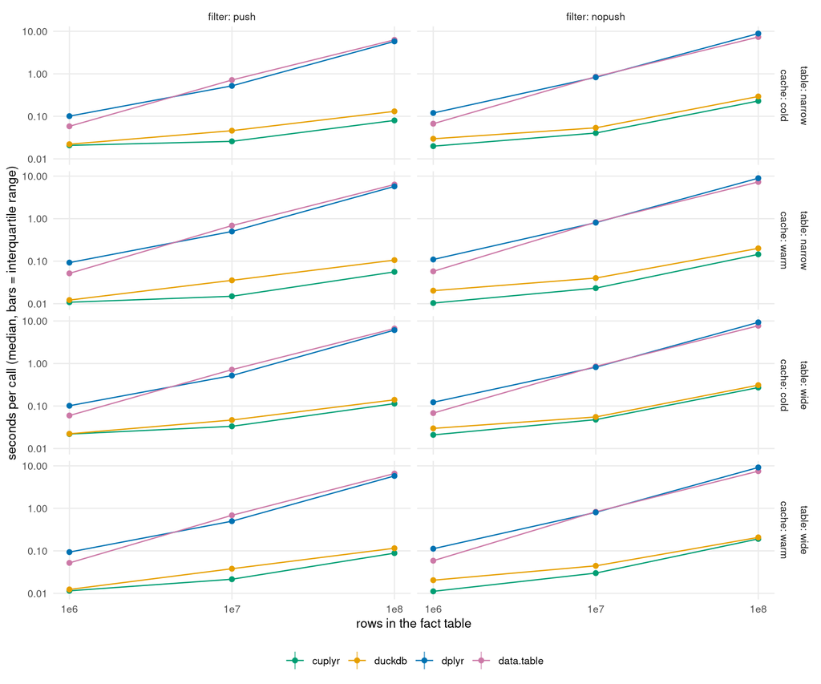

Pipeline p1: filter, mutate, group by store and channel, summarise (4000 groups)

### Pipeline `p2`

filter, mutate, join to the store dimension, group by region and channel, summarise (40 groups). Warm cache:

| filter | table | rows | cuplyr | duckdb | dplyr | data.table |
| --- | --- | --- | --- | --- | --- | --- |
| push | narrow | 1e6 | 0.0146 (0.0144-0.0152) n=15 | **0.0115 (0.0114-0.0117) n=15** | 0.0681 (0.063-0.0694) n=15 | 0.0638 (0.0604-0.0656) n=15 |
| push | narrow | 1e7 | **0.0233 (0.023-0.0271) n=10** | 0.0333 (0.0322-0.0382) n=10 | 0.617 (0.605-0.623) n=10 | 0.759 (0.739-0.79) n=10 |
| push | narrow | 1e8 | 0.144 (0.139-0.15) n=5 | **0.0785 (0.0782-0.0786) n=5** | 7.39 (7.36-7.45) n=5 | 7.09 (7.03-7.13) n=5 |
| push | wide | 1e6 | 0.0154 (0.0151-0.0159) n=15 | **0.0119 (0.0115-0.0127) n=15** | 0.0691 (0.064-0.07) n=15 | 0.0657 (0.0624-0.0669) n=15 |
| push | wide | 1e7 | **0.0316 (0.0306-0.0388) n=10** | 0.0337 (0.0331-0.0347) n=10 | 0.614 (0.612-0.62) n=10 | 0.765 (0.73-0.791) n=10 |
| push | wide | 1e8 | 0.169 (0.168-0.176) n=5 | **0.0868 (0.085-0.0869) n=5** | 7.54 (7.44-7.57) n=5 | 7.27 (7.26-7.34) n=5 |
| nopush | narrow | 1e6 | **0.0149 (0.0147-0.0151) n=15** | 0.0198 (0.0197-0.02) n=15 | 0.0952 (0.0945-0.0992) n=15 | 0.0683 (0.0642-0.073) n=15 |
| nopush | narrow | 1e7 | **0.0317 (0.0316-0.0319) n=10** | 0.0378 (0.0363-0.0394) n=10 | 0.923 (0.916-0.948) n=10 | 0.893 (0.888-0.9) n=10 |
| nopush | narrow | 1e8 | 0.231 (0.226-0.237) n=5 | **0.184 (0.184-0.184) n=5** | 10.6 (10.5-10.6) n=5 | 8.01 (7.93-8.03) n=5 |
| nopush | wide | 1e6 | **0.0152 (0.015-0.0155) n=15** | 0.02 (0.0197-0.0211) n=15 | 0.097 (0.096-0.102) n=15 | 0.0673 (0.0654-0.0696) n=15 |
| nopush | wide | 1e7 | **0.0395 (0.0386-0.0402) n=10** | 0.0417 (0.0397-0.0425) n=10 | 0.91 (0.904-0.92) n=10 | 0.896 (0.887-0.904) n=10 |
| nopush | wide | 1e8 | 0.267 (0.265-0.276) n=5 | **0.193 (0.192-0.193) n=5** | 10.8 (10.7-10.9) n=5 | 8.22 (8.17-8.25) n=5 |

Cold cache:

| filter | table | rows | cuplyr | duckdb | dplyr | data.table |
| --- | --- | --- | --- | --- | --- | --- |
| push | narrow | 1e6 | 0.025 (0.0246-0.0253) n=15 | **0.0215 (0.0213-0.0219) n=15** | 0.0782 (0.0774-0.0793) n=15 | 0.0745 (0.0724-0.0754) n=15 |
| push | narrow | 1e7 | **0.0346 (0.0341-0.0351) n=10** | 0.0435 (0.0429-0.044) n=10 | 0.636 (0.632-0.652) n=10 | 0.79 (0.764-0.819) n=10 |
| push | narrow | 1e8 | 0.169 (0.163-0.178) n=5 | **0.107 (0.106-0.11) n=5** | 7.55 (7.49-7.63) n=5 | 7.1 (7.04-7.15) n=5 |
| push | wide | 1e6 | 0.0266 (0.0263-0.0268) n=15 | **0.0216 (0.0214-0.0227) n=15** | 0.0773 (0.075-0.0783) n=15 | 0.0751 (0.0718-0.076) n=15 |
| push | wide | 1e7 | **0.0426 (0.042-0.0448) n=10** | 0.0436 (0.0433-0.0447) n=10 | 0.639 (0.634-0.642) n=10 | 0.8 (0.767-0.826) n=10 |
| push | wide | 1e8 | 0.199 (0.195-0.2) n=5 | **0.114 (0.114-0.114) n=5** | 7.76 (7.72-7.83) n=5 | 7.41 (7.4-7.48) n=5 |
| nopush | narrow | 1e6 | **0.0233 (0.0232-0.0235) n=15** | 0.0293 (0.0291-0.0295) n=15 | 0.105 (0.104-0.106) n=15 | 0.0762 (0.0739-0.0782) n=15 |
| nopush | narrow | 1e7 | **0.0491 (0.0486-0.051) n=10** | 0.0519 (0.0502-0.0527) n=10 | 0.95 (0.942-0.968) n=10 | 0.922 (0.921-0.932) n=10 |
| nopush | narrow | 1e8 | 0.314 (0.31-0.322) n=5 | **0.284 (0.281-0.285) n=5** | 10.5 (10.5-10.7) n=5 | 7.96 (7.95-8) n=5 |
| nopush | wide | 1e6 | **0.0259 (0.0253-0.0268) n=15** | 0.0299 (0.0297-0.0308) n=15 | 0.106 (0.105-0.109) n=15 | 0.0786 (0.0757-0.0792) n=15 |
| nopush | wide | 1e7 | 0.0573 (0.0569-0.0577) n=10 | **0.0554 (0.0539-0.0579) n=10** | 0.949 (0.944-0.953) n=10 | 0.925 (0.917-0.933) n=10 |
| nopush | wide | 1e8 | 0.35 (0.348-0.366) n=5 | **0.282 (0.282-0.284) n=5** | 10.8 (10.8-10.9) n=5 | 8.31 (8.29-8.33) n=5 |

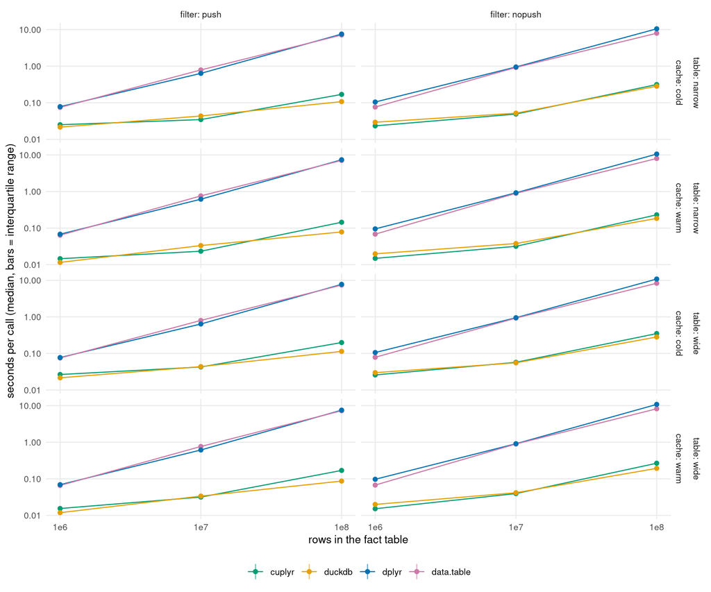

Pipeline p2: filter, mutate, join to the store dimension, group by region and channel, summarise (40 groups)

### Pipeline `p3`

filter, mutate, group by product, sum the revenue, keep the top 10 (ties kept). Warm cache:

| filter | table | rows | cuplyr | duckdb | dplyr | data.table |
| --- | --- | --- | --- | --- | --- | --- |
| push | narrow | 1e6 | **0.00962 (0.00933-0.0105) n=15** | 0.0201 (0.0191-0.0208) n=15 | 0.301 (0.298-0.308) n=15 | 0.0224 (0.022-0.0248) n=15 |
| push | narrow | 1e7 | **0.0135 (0.0134-0.0143) n=10** | 0.0473 (0.0467-0.0514) n=10 | 0.554 (0.537-0.579) n=10 | 0.321 (0.318-0.369) n=10 |
| push | narrow | 1e8 | **0.0493 (0.0486-0.0522) n=5** | 0.204 (0.2-0.206) n=5 | 2.86 (2.84-2.86) n=5 | 1.75 (1.74-1.76) n=5 |
| push | wide | 1e6 | **0.0102 (0.0101-0.0106) n=15** | 0.0204 (0.0194-0.0221) n=15 | 0.301 (0.296-0.308) n=15 | 0.024 (0.0226-0.0243) n=15 |
| push | wide | 1e7 | **0.0197 (0.0195-0.0199) n=10** | 0.0478 (0.0473-0.049) n=10 | 0.552 (0.532-0.554) n=10 | 0.319 (0.314-0.367) n=10 |
| push | wide | 1e8 | **0.079 (0.0769-0.0826) n=5** | 0.212 (0.21-0.213) n=5 | 2.87 (2.86-2.88) n=5 | 1.76 (1.76-1.79) n=5 |
| nopush | narrow | 1e6 | **0.0099 (0.00981-0.0101) n=15** | 0.028 (0.0273-0.0287) n=15 | 0.346 (0.344-0.353) n=15 | 0.0598 (0.0592-0.0611) n=15 |
| nopush | narrow | 1e7 | **0.024 (0.0237-0.0243) n=10** | 0.0575 (0.0521-0.0594) n=10 | 1.03 (1.02-1.05) n=10 | 0.829 (0.827-0.84) n=10 |
| nopush | narrow | 1e8 | **0.155 (0.154-0.161) n=5** | 0.339 (0.335-0.342) n=5 | 8.76 (8.74-8.79) n=5 | 7.28 (7.25-7.31) n=5 |
| nopush | wide | 1e6 | **0.0109 (0.0107-0.0132) n=15** | 0.028 (0.0276-0.029) n=15 | 0.349 (0.346-0.355) n=15 | 0.0625 (0.0609-0.0635) n=15 |
| nopush | wide | 1e7 | **0.0308 (0.0304-0.0317) n=10** | 0.0555 (0.0526-0.0577) n=10 | 1.02 (1.02-1.04) n=10 | 0.83 (0.824-0.855) n=10 |
| nopush | wide | 1e8 | **0.199 (0.189-0.199) n=5** | 0.34 (0.339-0.343) n=5 | 9 (8.99-9.1) n=5 | 7.47 (7.46-7.6) n=5 |

Cold cache:

| filter | table | rows | cuplyr | duckdb | dplyr | data.table |
| --- | --- | --- | --- | --- | --- | --- |
| push | narrow | 1e6 | **0.0189 (0.0188-0.0192) n=15** | 0.0309 (0.0297-0.0311) n=15 | 0.309 (0.307-0.318) n=15 | 0.0337 (0.0318-0.0345) n=15 |
| push | narrow | 1e7 | **0.0265 (0.0261-0.0268) n=10** | 0.0579 (0.0567-0.0594) n=10 | 0.577 (0.559-0.584) n=10 | 0.339 (0.338-0.388) n=10 |
| push | narrow | 1e8 | **0.0817 (0.0812-0.0828) n=5** | 0.239 (0.239-0.241) n=5 | 3.01 (2.99-3.02) n=5 | 1.93 (1.93-1.95) n=5 |
| push | wide | 1e6 | **0.0209 (0.0207-0.0215) n=15** | 0.031 (0.0308-0.0319) n=15 | 0.308 (0.305-0.315) n=15 | 0.0345 (0.0337-0.035) n=15 |
| push | wide | 1e7 | **0.0334 (0.0332-0.0338) n=10** | 0.0612 (0.0602-0.0622) n=10 | 0.578 (0.571-0.592) n=10 | 0.347 (0.343-0.401) n=10 |
| push | wide | 1e8 | **0.12 (0.118-0.121) n=5** | 0.262 (0.259-0.263) n=5 | 3.06 (3.05-3.07) n=5 | 1.93 (1.93-2.01) n=5 |
| nopush | narrow | 1e6 | **0.0194 (0.0193-0.0197) n=15** | 0.0387 (0.0379-0.039) n=15 | 0.36 (0.356-0.365) n=15 | 0.0718 (0.0708-0.0724) n=15 |
| nopush | narrow | 1e7 | **0.0445 (0.0441-0.0457) n=10** | 0.0709 (0.0675-0.0745) n=10 | 1.05 (1.04-1.06) n=10 | 0.848 (0.845-0.864) n=10 |
| nopush | narrow | 1e8 | **0.287 (0.281-0.29) n=5** | 0.461 (0.46-0.463) n=5 | 8.77 (8.73-8.81) n=5 | 7.27 (7.23-7.53) n=5 |
| nopush | wide | 1e6 | **0.0214 (0.0213-0.0215) n=15** | 0.0384 (0.0371-0.0389) n=15 | 0.355 (0.353-0.363) n=15 | 0.0705 (0.0698-0.0716) n=15 |
| nopush | wide | 1e7 | **0.0551 (0.0546-0.0559) n=10** | 0.0702 (0.0691-0.0769) n=10 | 1.06 (1.05-1.08) n=10 | 0.856 (0.851-0.866) n=10 |
| nopush | wide | 1e8 | **0.356 (0.352-0.358) n=5** | 0.517 (0.478-0.517) n=5 | 9.18 (9.17-9.25) n=5 | 7.64 (7.64-7.69) n=5 |

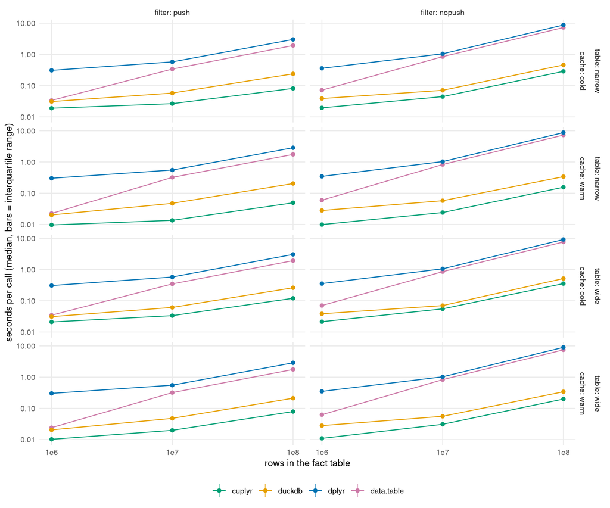

Pipeline p3: filter, mutate, group by product, sum the revenue, keep the top 10 (ties kept)

## Where cuplyr wins and loses

### Overall

cuplyr has the lowest median in 59 of the 72 cells where it and another engine both have quiet reps (30 of 36 warm, 29 of 36 cold). cuplyr’s median is 0.24 to 1.95 times the fastest other engine’s, over the cells where cuplyr and at least one other engine have quiet reps. There is no combination of size, cache state and filter in which cuplyr has the lowest median in fewer than half of its cells. In the cells it loses, the fastest engine is duckdb (13). By pipeline, the cells in which cuplyr is not the fastest are p2 (13 of its 24 cells). With the pushed filter at 1e8 rows (narrow table, warm cache), the join pipeline p2 takes 2.6 times the time of p1 in cuplyr and 0.7 times in DuckDB. Counted with a margin of a factor of 1.1, the best other engine’s median is at least 1.1 times cuplyr’s in 51 cells, cuplyr’s is at least 1.1 times the best other engine’s in 12, and the two are within that factor of each other in 9 (8 of them counted above as wins and 1 as a loss). Among the three CPU engines alone (cuplyr left out), the lowest median is duckdb’s in 72 of the 72 cells where all three have quiet reps. By pipeline: p1: duckdb 24 of 24, p2: duckdb 24 of 24 and p3: duckdb 24 of 24.

| rows | cache | filter | cells | cuplyr fastest | median ratio to the best other | worst ratio |
| --- | --- | --- | --- | --- | --- | --- |
| 1e6 | cold | push | 6 | 4 | 0.96 | 1.23 |
| 1e6 | cold | nopush | 6 | 6 | 0.69 | 0.87 |
| 1e6 | warm | push | 6 | 4 | 0.91 | 1.30 |
| 1e6 | warm | nopush | 6 | 6 | 0.53 | 0.76 |
| 1e7 | cold | push | 6 | 6 | 0.64 | 0.98 |
| 1e7 | cold | nopush | 6 | 5 | 0.82 | 1.03 |
| 1e7 | warm | push | 6 | 6 | 0.49 | 0.94 |
| 1e7 | warm | nopush | 6 | 6 | 0.63 | 0.95 |
| 1e8 | cold | push | 6 | 4 | 0.71 | 1.74 |
| 1e8 | cold | nopush | 6 | 4 | 0.83 | 1.24 |
| 1e8 | warm | push | 6 | 4 | 0.65 | 1.95 |
| 1e8 | warm | nopush | 6 | 4 | 0.82 | 1.38 |

### What cuplyr’s time is spent on

The results are small (at most 4000 rows). To see how cuplyr’s time divides, the `probe` step ran four separate calls for the two variants of the first pipeline at 1e7 and 1e8 rows (narrow table, warm cache, the same quiet-machine rule as above): the scan alone (the lazy `read_parquet_gpu` read, the pushed filter if the variant has one, and the needed columns, computed into a GPU table), the whole plan computed into a GPU table, a `collect()` of a table that was computed beforehand (the transfer to R), and the benchmark’s whole call. Each stage ends with `gpu_sync()`, so queued GPU work is counted in the stage that queued it. The stages are separate calls, so their times do not add up exactly; the shares are relative to the whole call. Each stage ran 2 times untimed before its timed reps (after one untimed run of the plan to build the computed table), so the stages leave out the start-up cost of a first call (see the first-call section). 1 of the 121 probe calls was not quiet and is left out.

| rows | variant | scan | plan to a GPU table | collect of a computed table | whole call | scan share | collect share |
| --- | --- | --- | --- | --- | --- | --- | --- |
| 1e7 | p1_nopush | 0.0166 s | 0.0229 s | 0.000526 s | 0.0228 s | 73% | 2.3% |
| 1e7 | p1_push | 0.0109 s | 0.0145 s | 0.000641 s | 0.0149 s | 73% | 4.3% |
| 1e8 | p1_nopush | 0.111 s | 0.145 s | 0.000652 s | 0.144 s | 78% | 0.5% |
| 1e8 | p1_push | 0.0408 s | 0.0533 s | 0.000683 s | 0.0546 s | 75% | 1.3% |

At 1e8 rows (warm cache, narrow table), the scan alone takes 75% to 78% of the whole call in the two first-pipeline variants, the rest of the plan (filter, mutate, aggregate) 23% to 23%, and collecting a result that is already computed takes 0.5% to 1.3%. So, in these calls, bringing the answer to R is under 5% of cuplyr’s time in both variants, and the scan (reading and decoding the file) is the largest of the three parts in both.

### Pushdown

| variant | table | rows | read | columns read | row groups kept | rows decoded | rows returned | pushed |
| --- | --- | --- | --- | --- | --- | --- | --- | --- |
| p1_nopush | narrow | 1e6 | whole pipeline | 5 of 8 | all 1 | 100% | 100% | none |
| p1_nopush | narrow | 1e7 | whole pipeline | 5 of 8 | all 10 | 100% | 100% | none |
| p1_nopush | narrow | 1e8 | whole pipeline | 5 of 8 | all 96 | 100% | 100% | none |
| p1_nopush | wide | 1e6 | whole pipeline | 5 of 40 | all 1 | 100% | 100% | none |
| p1_nopush | wide | 1e7 | whole pipeline | 5 of 40 | all 10 | 100% | 100% | none |
| p1_nopush | wide | 1e8 | whole pipeline | 5 of 40 | all 96 | 100% | 100% | none |
| p1_push | narrow | 1e6 | whole pipeline | 6 of 8 | 1 of 1 | 100% | 19% | day >= 2024-01-01 & qty >= 2 |
| p1_push | narrow | 1e7 | whole pipeline | 6 of 8 | 3 of 10 | 27% | 19% | day >= 2024-01-01 & qty >= 2 |
| p1_push | narrow | 1e8 | whole pipeline | 6 of 8 | 20 of 96 | 20% | 19% | day >= 2024-01-01 & qty >= 2 |
| p1_push | wide | 1e6 | whole pipeline | 6 of 40 | 1 of 1 | 100% | 19% | day >= 2024-01-01 & qty >= 2 |
| p1_push | wide | 1e7 | whole pipeline | 6 of 40 | 3 of 10 | 27% | 19% | day >= 2024-01-01 & qty >= 2 |
| p1_push | wide | 1e8 | whole pipeline | 6 of 40 | 20 of 96 | 20% | 19% | day >= 2024-01-01 & qty >= 2 |
| p2_nopush | narrow | 1e6 | fact scan under the join | 5 of 8 | all 1 | 100% | 100% | none |
| p2_nopush | narrow | 1e7 | fact scan under the join | 5 of 8 | all 10 | 100% | 100% | none |
| p2_nopush | narrow | 1e8 | fact scan under the join | 5 of 8 | all 96 | 100% | 100% | none |
| p2_nopush | wide | 1e6 | fact scan under the join | 5 of 40 | all 1 | 100% | 100% | none |
| p2_nopush | wide | 1e7 | fact scan under the join | 5 of 40 | all 10 | 100% | 100% | none |
| p2_nopush | wide | 1e8 | fact scan under the join | 5 of 40 | all 96 | 100% | 100% | none |
| p2_push | narrow | 1e6 | fact scan under the join | 6 of 8 | 1 of 1 | 100% | 19% | day >= 2024-01-01 & qty >= 2 |
| p2_push | narrow | 1e7 | fact scan under the join | 6 of 8 | 3 of 10 | 27% | 19% | day >= 2024-01-01 & qty >= 2 |
| p2_push | narrow | 1e8 | fact scan under the join | 6 of 8 | 20 of 96 | 20% | 19% | day >= 2024-01-01 & qty >= 2 |
| p2_push | wide | 1e6 | fact scan under the join | 6 of 40 | 1 of 1 | 100% | 19% | day >= 2024-01-01 & qty >= 2 |
| p2_push | wide | 1e7 | fact scan under the join | 6 of 40 | 3 of 10 | 27% | 19% | day >= 2024-01-01 & qty >= 2 |
| p2_push | wide | 1e8 | fact scan under the join | 6 of 40 | 20 of 96 | 20% | 19% | day >= 2024-01-01 & qty >= 2 |
| p3_nopush | narrow | 1e6 | whole pipeline | 5 of 8 | all 1 | 100% | 100% | none |
| p3_nopush | narrow | 1e7 | whole pipeline | 5 of 8 | all 10 | 100% | 100% | none |
| p3_nopush | narrow | 1e8 | whole pipeline | 5 of 8 | all 96 | 100% | 100% | none |
| p3_nopush | wide | 1e6 | whole pipeline | 5 of 40 | all 1 | 100% | 100% | none |
| p3_nopush | wide | 1e7 | whole pipeline | 5 of 40 | all 10 | 100% | 100% | none |
| p3_nopush | wide | 1e8 | whole pipeline | 5 of 40 | all 96 | 100% | 100% | none |
| p3_push | narrow | 1e6 | whole pipeline | 5 of 8 | 1 of 1 | 100% | 19% | day >= 2024-01-01 & qty >= 2 |
| p3_push | narrow | 1e7 | whole pipeline | 5 of 8 | 3 of 10 | 27% | 19% | day >= 2024-01-01 & qty >= 2 |
| p3_push | narrow | 1e8 | whole pipeline | 5 of 8 | 20 of 96 | 20% | 19% | day >= 2024-01-01 & qty >= 2 |
| p3_push | wide | 1e6 | whole pipeline | 5 of 40 | 1 of 1 | 100% | 19% | day >= 2024-01-01 & qty >= 2 |
| p3_push | wide | 1e7 | whole pipeline | 5 of 40 | 3 of 10 | 27% | 19% | day >= 2024-01-01 & qty >= 2 |
| p3_push | wide | 1e8 | whole pipeline | 5 of 40 | 20 of 96 | 20% | 19% | day >= 2024-01-01 & qty >= 2 |

The table is what `parquet_last_read()` reported after each cuplyr check run of the fact file. For the join pipeline the last read of the whole pipeline is the dimension file, so the table has a second row for it, from a run with the dimension computed first: the fact file is then the only parquet read of the plan, and the row shows its scan as it runs under the join. **Rows decoded** is the rows in the row groups kept after the statistics, from the file’s metadata: the reader decodes whole row groups. **Rows returned** is what the scan hands on, after the pushed filter. Both filters keep about the same share of the rows (19% and 19%), but the pushed filter is not the same work as the other one: dplyr and data.table push nothing and read every row, and their time for the pushed variant is 0.62 to 0.9 times that of the other, over the sizes in the table below. So the filters differ in cost on their own, and the gap in cuplyr’s time cannot be put down to the pushdown alone. Where the pushed filter skips no row group (1e6 rows: the file has a single row group), cuplyr’s ratio is 1.04. Where it skips row groups (3 of 10 kept at 1e7 rows and 20 of 96 kept at 1e8 rows), cuplyr’s ratio is 0.64 and 0.39. It is lower than both CPU engines’ ratios at 1e8 rows and not at 1e7 rows. Where it is lower, skipping row groups may be adding to the filters’ own cost difference; this table does not separate the two. DuckDB’s ratio at 1e8 rows is lower than the CPU engines’ too (0.53), which fits it using row group statistics as well (not checked here).

| rows | row groups kept | rows decoded | cuplyr | duckdb | dplyr | data.table |
| --- | --- | --- | --- | --- | --- | --- |
| 1e6 | 1 of 1 | 100% | 1.04 | 0.60 | 0.84 | 0.90 |
| 1e7 | 3 of 10 | 27% | 0.64 | 0.88 | 0.62 | 0.83 |
| 1e8 | 20 of 96 | 20% | 0.39 | 0.53 | 0.64 | 0.87 |

The last four columns are the median time of the pushed variant divided by that of the other variant of the first pipeline (narrow table, warm cache).

### Why cuplyr loses the join pipeline

The join pipeline accounts for 13 of cuplyr’s 13 lost cells. On inputs already on the device at 1e8 rows, cuplyr’s join of the filtered facts to the dimension takes 0.0807 s (pushed filter) and 0.0793 s (other filter), which is 8.6 and 7.9 times its aggregate of the same rows (0.00939 s and 0.0101 s), and 90% and 90% of its join and aggregate together. With the pushed filter, cuplyr’s join alone is 1.2 times faster than DuckDB’s join into a table, while DuckDB’s join and aggregate in one query (0.0373 s) is 2.4 times faster than cuplyr’s (0.0898 s). In the benchmark itself the join pipeline takes 0.0884 s (pushed filter) and 0.0858 s (other filter) longer than the first pipeline in cuplyr at 1e8 rows (narrow table, warm cache), close to the join’s time here. The check step ran the join pipeline with the pushed filter once more with the dimension computed first, so that the fact file is the plan’s only parquet read (the `fact scan under the join` row of `pushdown.csv`): the scan keeps 20 of 96 row groups and decodes 20% of the rows, and the first pipeline’s scan keeps 20 of 96, so the pushdown works the same under the join. The probe shows where the time goes (the join, not the scan or the aggregate); it does not show why the join takes that long. 0 of the probe’s calls were not quiet and are left out.

| rows | variant | cuplyr join | cuplyr aggregate | cuplyr join and aggregate | DuckDB join | DuckDB aggregate | DuckDB join and aggregate |
| --- | --- | --- | --- | --- | --- | --- | --- |
| 1e7 | p2_push | 0.00748 s | 0.00372 s | 0.0107 s | 0.0167 s | 0.0131 s | 0.0105 s |
| 1e7 | p2_nopush | 0.00748 s | 0.0036 s | 0.0106 s | 0.0222 s | 0.0116 s | 0.0104 s |
| 1e8 | p2_push | 0.0807 s | 0.00939 s | 0.0898 s | 0.0994 s | 0.0406 s | 0.0373 s |
| 1e8 | p2_nopush | 0.0793 s | 0.0101 s | 0.0881 s | 0.101 s | 0.0409 s | 0.0371 s |

The inputs of the probe are the filtered fact columns as a table on the device (cuplyr) or as a temporary table (DuckDB), and the dimension; the aggregate is the first pipeline’s. DuckDB’s “join” creates a table of the joined rows, which cuplyr’s “join” also computes. A repro for the join is under Findings.

### Projection on the wide table

At 1e8 rows with the nopush filter and a warm cache, the wide table has 40 columns against 8; every engine is asked for the same 5 columns. cuplyr is 1.32 times slower on the wide table, duckdb does not slow down on the wide table, dplyr does not slow down on the wide table and data.table does not slow down on the wide table. cuplyr reads 5 of the 40 columns of the wide file (see the table above), and DuckDB and arrow are given the same column list.

### Cold cache

At 1e8 rows (narrow table, nopush filter, first pipeline) the cold call takes 1.59 times the warm call for cuplyr, 1.46 times the warm call for duckdb, 0.99 times the warm call for dplyr and 1.00 times the warm call for data.table.

### The first call of a cell

Within a cell, the first call (rep 0, after the warm-up, not in the medians) takes this multiple of the cell’s median (median over cells): cuplyr 0.99, duckdb 1.00, dplyr 1.01 and data.table 1.04. The fresh-process first calls are in the next section.

### Memory

No cell ran out of memory.

## Rowwise

The rowwise pipeline is a per-row computation. It reads the wide table, computes for every row the largest (`m`) and the sum (`s`) of the four double columns `x17`, `x18`, `x19` and `x20` (the filler columns have no missing values), and summarises by `category`: the count, the mean of `m` and the sum of `s`, 20 groups. It ran at 1e5, 1e6 and 1e7 rows. dplyr’s rowwise route evaluates the expression once per row and gets slow fast, so every call had a cap of 60 seconds, and a call over the cap was aborted and recorded as capped.

### The five forms

Each form is how its engine’s users write it. The two dplyr forms and data.table read with the same arrow reader as the main pipelines, asking for the needed columns only (`category`, `x17`, `x18`, `x19` and `x20`).

**cuplyr rowwise** reads with `read_parquet_gpu()`, makes the table rowwise with `rowwise()` and takes the per-row maximum and sum with `c_across()`. cuplyr does not evaluate these once per row: its rowwise support (F49) rewrites `max()` and `sum()` of `c_across()` into expressions across the columns (`rowwise_rewrite_dots()` in `R/rowwise.R`), so the GPU computes them over whole columns, as the vectorised forms do. If a rewrite is not possible the whole call falls back to dplyr on the CPU; whether this form stayed on the GPU is checked below (from F88’s `cuplyr_cpu_fallback` condition, not guessed).

```r
function(fact, ctx) {
  cols <- pp_constants()$rowwise_cols
  cuplyr::read_parquet_gpu(fact) |>
    dplyr::rowwise() |>
    dplyr::mutate(m = max(dplyr::c_across(dplyr::all_of(cols))),
                  s = sum(dplyr::c_across(dplyr::all_of(cols)))) |>
    dplyr::ungroup() |>
    dplyr::group_by(category) |>
    dplyr::summarise(n = dplyr::n(), m_mean = mean(m), s_sum = sum(s)) |>
    dplyr::collect()
}
```

**dplyr rowwise** is the same verbs on a tibble: `rowwise()` and `c_across()`, which dplyr evaluates once per row.

```r
function(fact, ctx) {
  cols <- pp_constants()$rowwise_cols
  pp_read_arrow(fact, pp_columns("rowwise")) |>
    dplyr::rowwise() |>
    dplyr::mutate(m = max(dplyr::c_across(dplyr::all_of(cols))),
                  s = sum(dplyr::c_across(dplyr::all_of(cols)))) |>
    dplyr::ungroup() |>
    dplyr::group_by(category) |>
    dplyr::summarise(n = dplyr::n(), m_mean = mean(m), s_sum = sum(s))
}
```

**dplyr vectorised** is the expert’s form, over whole columns with `pmax()` and `+`: the fair comparison for what a dplyr user would write. (The correctness reference for every form is a separate computation in base R; see below.)

```r
function(fact, ctx) {
  pp_read_arrow(fact, pp_columns("rowwise")) |>
    dplyr::mutate(m = pmax(x17, x18, x19, x20), s = x17 + x18 + x19 + x20) |>
    dplyr::group_by(category) |>
    dplyr::summarise(n = dplyr::n(), m_mean = mean(m), s_sum = sum(s))
}
```

**data.table vectorised** uses `pmax()` and `rowSums()` over the columns, then an aggregate by `category`: the form this benchmark’s brief names. `rowSums(.SD)` first copies the four columns into a matrix; adding them (`x17 + x18 + x19 + x20`, as the dplyr and DuckDB forms do) would avoid that copy and may be faster. That form was not timed.

```r
function(fact, ctx) {
  cols <- pp_constants()$rowwise_cols
  DT <- data.table::setDT(pp_read_arrow(fact, pp_columns("rowwise")))
  DT[, `:=`(m = pmax(x17, x18, x19, x20), s = rowSums(.SD)), .SDcols = cols]
  DT[, .(n = .N, m_mean = mean(m), s_sum = sum(s)), by = category]
}
```

**DuckDB** is SQL over `read_parquet()` with explicit columns: `greatest()` and arithmetic, then a group by.

```sql
SELECT category, count(*) AS n, avg(m) AS m_mean, sum(s) AS s_sum
FROM (SELECT category, greatest(x17, x18, x19, x20) AS m, x17 + x18 + x19 + x20 AS s
      FROM read_parquet('<fact>.parquet'))
GROUP BY category
```

### How the rowwise calls were timed

The rules are those of the main pipelines (the section on how the calls were timed), except for which forms share a cell. A size in a cache state makes two cells, run one after the other with the same cache control, check, cap and load rule. dplyr rowwise is timed in a cell of its own: at 1e5 rows (warm cache) its median call takes 36 s, 4,295 times cuplyr rowwise’s, so in a shared cell each of its calls would leave the GPU idle for that long between two cuplyr calls, and an idle GPU makes the next cuplyr call slower (see Findings). The other forms (cuplyr rowwise, dplyr vectorised, data.table vectorised and DuckDB) are timed together in the other cell, interleaved: their start times interleave in 6 of the 6 such cells, and no dplyr rowwise call started while one of them ran (both checked in `rowwise.csv`). At 1e7 rows dplyr rowwise was not run (it had been capped at a smaller size), so there the shared cell is the only one and has four forms. The ratios against dplyr rowwise below compare medians from the two cells of a size and cache state. In a cell the forms take turns in a rotating order, an untimed `gc()` precedes every call, warm and cold are the page cache of the wide file (`fincore` before every call, `posix_fadvise(DONTNEED)` before every cold call), and a call is quiet when other processes’ user-space CPU share is at most the same limit as everywhere else. The quiet reps per cell are 1e5 rows: 10, 1e6 rows: 5 and 1e7 rows: 5. Right before each cell, its forms were called 2 times each, untimed, on the 1e5-row file (56 calls in all, `rowwise-warmup.csv`), so each form’s start-up costs fall before its timed calls; the first call of a cell (rep 0) is recorded and kept out of the medians. A warm-up does not keep the GPU from idling later in a cell; the separate cells and the gaps below are about that. Of the 180 timed rowwise calls, 0 were not quiet; the highest foreign share in a quiet call is 4.3% (limit 15%), and the highest wait before a call was 0.26 seconds. The number of quiet reps behind every median is in the tables (n). Residency before the calls: lowest 100% (warm), highest 0% (cold). A call was aborted at the cap of 60 seconds in 2 cells: dplyr rowwise at 1e6 rows (warm cache, aborted after 60.1 s) and dplyr rowwise at 1e6 rows (cold cache, aborted after 60.1 s). These cells are shown as capped, not as a number (a capped call is never part of a median); a form capped at one size was not run at larger sizes, and those cells say so. Every quiet cuplyr rep came at most 6.2 seconds after cuplyr’s previous call in its cell, within the 10 seconds of idle after which the idle probe saw no slowdown. Earlier runs of this chunk are kept in `rowwise-superseded.csv` (420 rows) and not used. The first of them timed dplyr rowwise in the same cells as the other forms, and there cuplyr’s median at 1e5 rows was 0.02 s (warm) and 0.0289 s (cold), 2.4 and 1.6 times the medians above. The second of them, from benchmark commit `b674eaa`, timed dplyr rowwise in cells of its own, as the data in use do, and so is a replicate of them. It agrees on every verdict: in 6 of the 6 combinations of size and cache state the same form has the lowest median among the forms with a median in both runs, in 20 of the 20 comparisons with another form cuplyr rowwise is faster in both runs or slower in both, and 30 of the 30 combinations of form, size and cache state in both runs have the same status (capped, not run or ok). cuplyr’s median at 1e5 rows (warm cache) was 0.00823 s there and 0.00837 s here, and its ratio to DuckDB at 1e7 rows (warm cache) 0.78 there and 0.71 here. The largest difference between the runs is for cuplyr rowwise at 1e7 rows (warm cache): 0.0437 s there against 0.0399 s here, 9.3% apart and outside this run’s interquartile range (0.0397-0.0404 s); the other 25 medians (a form at a size and cache state) differ by 3.3% or less. The replicate’s median lies outside this run’s interquartile range in 9 of the 26. If the two runs were draws from one distribution, about 11.3 would, and 9 or more would with a chance of 87% (from splitting the pooled quiet reps of each form, size and cache state between the two runs: every possible split for a cell of 5 and 5 reps and 4,000 random splits for a cell of 10 and 10 reps). So the count gives no sign that the runs differ by more than the spread within one run.

### Correctness of the rowwise results

13 of the 15 results (form and size) equal the base-R reference (keys exactly, measures within a relative tolerance of 1e-09). Aborted at the cap before they could be compared: dplyr rowwise at 1e6 rows. Not run, because the form had been capped at a smaller size: dplyr rowwise at 1e7 rows. Every timed call’s result was compared with the same reference, untimed.

### Does cuplyr’s rowwise form stay on the GPU?

cuplyr’s rowwise form ran natively at every size (1e5, 1e6 and 1e7 rows): the check step’s run saw no `cuplyr_cpu_fallback` condition. The timed calls were watched too: a calling handler on `cuplyr_cpu_fallback` around each of the 46 timed cuplyr calls (every rep, the first call of each cell included) recorded no fallback (the `fallback` column of `rowwise.csv`). So every timed cuplyr call ran without a fallback, and the timings of that form are GPU timings.

| rows | verdict | columns read | reason |
| --- | --- | --- | --- |
| 1e5 | native (no fallback condition) | 5 of 40 |  |
| 1e6 | native (no fallback condition) | 5 of 40 |  |
| 1e7 | native (no fallback condition) | 5 of 40 |  |

### Rowwise timings

Median seconds of the quiet reps, the interquartile range in brackets, and the number of quiet reps (n); the lowest median of a row is in bold. A capped cell says so and a form that was not run says why.

Warm cache:

| rows | cuplyr rowwise | dplyr rowwise | dplyr vectorised | data.table vectorised | DuckDB |
| --- | --- | --- | --- | --- | --- |
| 1e5 | 0.00837 (0.00822-0.0085) n=10 | 36 (35.8-36.1) n=10 | 0.0118 (0.011-0.0125) n=10 | 0.0133 (0.0128-0.0139) n=10 | **0.00639 (0.0063-0.00654) n=10** |
| 1e6 | **0.0109 (0.0107-0.0112) n=5** | capped: a call ran over 60 s (aborted at 60.1 s) | 0.0716 (0.071-0.0736) n=5 | 0.0797 (0.0781-0.0827) n=5 | 0.0359 (0.0354-0.041) n=5 |
| 1e7 | **0.0399 (0.0397-0.0404) n=5** | not run: capped at 1e6 rows | 0.722 (0.716-0.882) n=5 | 0.831 (0.827-0.833) n=5 | 0.0562 (0.0559-0.0575) n=5 |

Cold cache:

| rows | cuplyr rowwise | dplyr rowwise | dplyr vectorised | data.table vectorised | DuckDB |
| --- | --- | --- | --- | --- | --- |
| 1e5 | 0.0179 (0.0177-0.0187) n=10 | 36.1 (36.1-36.2) n=10 | 0.0205 (0.0196-0.0206) n=10 | 0.0217 (0.0205-0.0219) n=10 | **0.0149 (0.0148-0.015) n=10** |
| 1e6 | **0.0206 (0.0205-0.021) n=5** | capped: a call ran over 60 s (aborted at 60.1 s) | 0.0801 (0.0789-0.081) n=5 | 0.0891 (0.0887-0.0958) n=5 | 0.0453 (0.0451-0.0466) n=5 |
| 1e7 | **0.0551 (0.055-0.0553) n=5** | not run: capped at 1e6 rows | 0.743 (0.736-0.898) n=5 | 0.847 (0.844-0.854) n=5 | 0.0688 (0.0682-0.069) n=5 |

Of the 6 combinations of size and cache state, comparing the forms with a quiet median in each, from both cells where there are two (5 forms in 2 and 4 forms in 4), the lowest median belongs to cuplyr rowwise in 4 and DuckDB in 2.

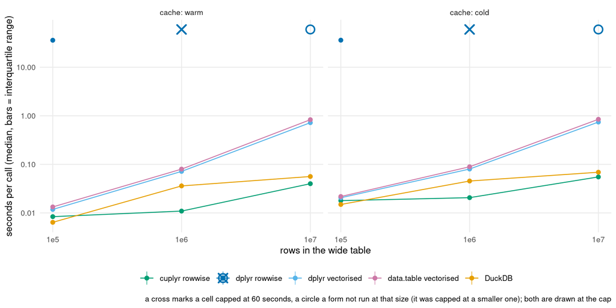

Rowwise pipeline: seconds per call by size, form and cache state

### Rowwise ratios

Each ratio is cuplyr rowwise’s median divided by the other form’s median in the same size and cache state, so a value below one means cuplyr rowwise is faster. Where the other form was capped, its time is above the cap and the ratio is bounded by cuplyr’s median over the cap (shown as a bound).

| rows | cache | cuplyr rowwise (s) | against dplyr rowwise | against dplyr vectorised | against data.table vectorised | against DuckDB |
| --- | --- | --- | --- | --- | --- | --- |
| 1e5 | warm | 0.00837 | 0.000233 | 0.711 | 0.631 | 1.31 |
| 1e5 | cold | 0.0179 | 0.000495 | 0.872 | 0.823 | 1.2 |
| 1e6 | warm | 0.0109 | < 0.000182 (capped) | 0.152 | 0.137 | 0.303 |
| 1e6 | cold | 0.0206 | < 0.000343 (capped) | 0.257 | 0.231 | 0.454 |
| 1e7 | warm | 0.0399 | not run | 0.0553 | 0.048 | 0.711 |
| 1e7 | cold | 0.0551 | not run | 0.0741 | 0.065 | 0.8 |

Against dplyr rowwise, cuplyr’s median is between 0.000233 and 0.000495 times its median in the 2 combinations of size and cache state where both have quiet reps (cuplyr is faster in 2 of them and slower in 0); in 2 more combinations of size and cache state dplyr rowwise was capped, so there the ratio is below cuplyr’s median divided by the cap, which is between 0.000182 and 0.000343 (a bound, not a measurement). Against dplyr vectorised, cuplyr’s median is between 0.0553 and 0.872 times its median in the 6 combinations of size and cache state where both have quiet reps (cuplyr is faster in 6 of them and slower in 0). Against data.table vectorised, cuplyr’s median is between 0.048 and 0.823 times its median in the 6 combinations of size and cache state where both have quiet reps (cuplyr is faster in 6 of them and slower in 0). Against DuckDB, cuplyr’s median is between 0.303 and 1.31 times its median in the 6 combinations of size and cache state where both have quiet reps (cuplyr is faster in 4 of them and slower in 2).

## First call

Each engine and variant ran in a fresh R process at 1e7 rows (narrow table, warm cache): the packages were loaded first (`load_secs`; for cuplyr that is `pkgload::load_all()` of the checkout, which is not what an installed package would pay), DuckDB’s connection was opened, and then the calls ran one after another, each timed separately. A call is slow when it takes more than three times the median of the later half of the calls.

| engine | call 1 | call 2 | call 3 | call 4 | call 5 | call 6 | call 7 | call 8 | load (s) |
| --- | --- | --- | --- | --- | --- | --- | --- | --- | --- |
| cuplyr | 0.721 | 0.659 | 0.0147 | 0.0138 | 0.0139 | 0.014 | 0.0139 | 0.0136 | 0.679 |
| duckdb | 0.0366 | 0.0401 | 0.0355 | 0.0351 | 0.0344 | 0.0378 | 0.0348 | 0.0357 | 0.151 |
| dplyr | 0.663 | 0.535 | 0.515 | 0.548 | 0.512 | 0.512 | 0.514 | 0.503 | 0.24 |
| data.table | 0.742 | 0.511 | 0.526 | 0.513 | 0.564 | 0.507 | 0.52 | 0.513 | 0.19 |

| engine | variants with a slow start | slow calls (median) | first call, median (s) | later calls, median (s) |
| --- | --- | --- | --- | --- |
| cuplyr | 6 | 2 | 0.72 | 0.0224 |
| duckdb | 0 | 0 | 0.037 | 0.0354 |
| dplyr | 0 | 0 | 0.833 | 0.723 |
| data.table | 0 | 0 | 0.802 | 0.588 |

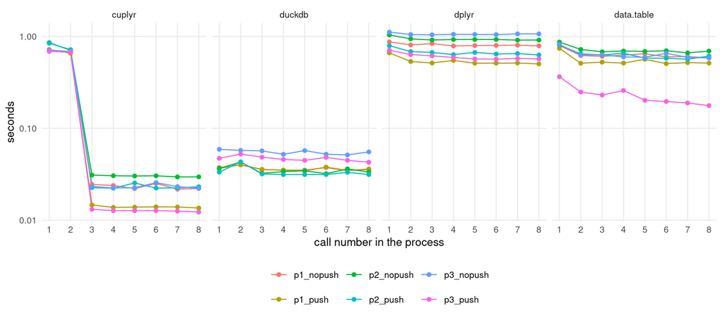

Seconds per call in a fresh process, by call number and variant

### New pipeline shapes in a warm process

The first-call finding is not confined to a process’s first calls, and the shapes probe shows it. The shapes are `scan` (read one column and collect it), `filter_int` (an integer filter on the whole file), `filter_date_int` (the pushed Date and integer filter), `summarise` (a grouped count), `mutate_sum` (a new column and its sum) and `p1_push` (the first pipeline). The probe repeats small cuplyr pipelines in fresh processes (6 shapes, each alone for 5 calls, then all in one process in order for 4 calls each; the file has 1e7 rows). A call is slow when it takes more than three times the shape’s fastest call in the probe. Alone, the first two calls are slow in 6 of the 6 shapes, and the first call takes 15 to 61 times the fastest. This includes the smallest shape (`scan`: read one column and collect it), which has 4 slow calls. In the sequence, 5 of the 5 shapes after the first have a slow call among their first two, up to 33 times their fastest call. So a new pipeline shape in an already warm process can be slow for its first calls, and the cost is not paid once per process.

Each shape in a fresh process of its own (seconds per call):

| shape | call 1 | call 2 | call 3 | call 4 | call 5 |
| --- | --- | --- | --- | --- | --- |
| scan | 0.211 | 0.235 | 0.0631 | 0.0592 | 0.0139 |
| filter_int | 0.472 | 0.479 | 0.0757 | 0.0711 | 0.0726 |
| filter_date_int | 0.557 | 0.316 | 0.0196 | 0.00953 | 0.0109 |
| summarise | 0.374 | 0.455 | 0.00889 | 0.00846 | 0.00838 |
| mutate_sum | 0.43 | 0.459 | 0.012 | 0.0117 | 0.0113 |
| p1_push | 0.699 | 0.674 | 0.0149 | 0.014 | 0.0153 |

All shapes in one process, in this order (seconds per call):

| shape | call 1 | call 2 | call 3 | call 4 |
| --- | --- | --- | --- | --- |
| scan | 0.214 | 0.238 | 0.0687 | 0.0603 |
| filter_int | 0.219 | 0.373 | 0.025 | 0.0265 |
| filter_date_int | 0.0168 | 0.0319 | 0.00957 | 0.00917 |
| summarise | 0.0844 | 0.271 | 0.00868 | 0.00817 |
| mutate_sum | 0.0301 | 0.149 | 0.0122 | 0.0118 |
| p1_push | 0.0523 | 0.0603 | 0.0141 | 0.014 |

## Findings

### cuplyr’s slow first calls of each new pipeline shape

In a fresh process the first 2 calls of cuplyr’s pipeline `p1_push` at 1e7 rows take about 0.69 s each (the first takes 0.721 s, the second 0.659 s, the third 0.0147 s), and the later calls about 0.0139 s. The slowness appears in 6 of the 6 cuplyr variants, with a median of 2 slow calls per variant. The shapes probe (in the first-call section) finds the pattern beyond the full pipeline: alone, 6 of 6 shapes have two slow first calls, and in one process, 5 of the 5 shapes after the first have a slow call among their first two.

The smallest repro found, in a fresh R process (the file is the benchmark’s narrow table at 1e7 rows from `pp_gen_fact()`; the probe’s calls took 0.211 s, 0.235 s, 0.0631 s, 0.0592 s and 0.0139 s, in this order):

```r
pkgload::load_all("."); library(dplyr)
f <- "fact-narrow-10000000.parquet"
for (i in 1:5) print(system.time(collect(read_parquet_gpu(f, columns = "store")))[["elapsed"]])
```

What the extra time is spent on is not examined here.

### A GPU left idle makes cuplyr’s next call slower

cuplyr pays for a GPU that has been left idle. The idle step (`idle.csv`) ran three calls on the wide table at 1e5 rows (warm cache): cuplyr’s rowwise form, a one-column cuplyr scan (one column read with `read_parquet_gpu` and collected), and DuckDB’s rowwise form as a CPU control. Each call ran after the machine had been left idle for 0, 10, 20 and 40 seconds, 4 times for each idle time. Right before its pause every call was preceded by an untimed call of the same function, so the GPU had been idle for the pause whatever ran before (the time from the end of that call to the start of the timed one is the pause plus 0.27 to 0.32 seconds for the quiet-machine wait and the state query). `nvidia-smi` read the GPU’s performance state and memory clock just before and just after every timed call (0 calls of 48 were not quiet or failed and are left out). With no idle time cuplyr’s rowwise form takes 0.00767 s and the scan 0.00342 s (median); after 40 seconds of idle they take 0.0195 s and 0.015 s, 2.5 and 4.4 times as long. DuckDB’s form takes 0.00591 s and 0.00637 s (1.08 times), so the CPU engine does not pay it. After 10 seconds of idle or less no cuplyr median is more than 1.25 times its no-idle median; after 20 seconds at least one is. Before the calls after 40 seconds of idle, `nvidia-smi` reported a memory clock of 405 MHz (median), against 13800 MHz with no idle time; just after a cuplyr call the memory clock was 13800 MHz (median over all of them). So the slow calls are the ones that start on a GPU whose memory clock has come down; what decides when the clocks drop and how fast they come back (the driver’s power management) is not examined here. The performance state `nvidia-smi` reported is not used: it lags the clocks. With no idle time 6 of the 8 reads before a cuplyr call report P8, the state reported after 40 seconds of idle, while the memory clock reads 13800 MHz. The memory clock is the measure here. In the table each time is the median of the quiet reps, with the lowest and highest in brackets and their number (n). An earlier run of the probe, without the untimed call before each pause (so a cuplyr call could follow DuckDB’s pause as well as its own), is kept in `idle-superseded.csv` (48 rows) and not used.

| idle (s) | cuplyr’s rowwise form (s) | the one-column cuplyr scan (s) | DuckDB’s rowwise form (s) | memory clock before a cuplyr call (MHz) |
| --- | --- | --- | --- | --- |
| 0 | 0.00767 (0.00745-0.00862) n=4 | 0.00342 (0.00289-0.0044) n=4 | 0.00591 (0.00573-0.00612) n=4 | 13800 |
| 10 | 0.0083 (0.00784-0.00872) n=4 | 0.00352 (0.00332-0.00363) n=4 | 0.00668 (0.00636-0.00705) n=4 | 13800 |
| 20 | 0.0137 (0.0132-0.017) n=4 | 0.0093 (0.00923-0.00942) n=4 | 0.00633 (0.00617-0.00713) n=4 | 810 |
| 40 | 0.0195 (0.0148-0.0223) n=4 | 0.015 (0.0148-0.0152) n=4 | 0.00637 (0.00611-0.00788) n=4 | 405 |

A repro uses the probe’s one-column scan, in a fresh R process (the file is the benchmark’s wide table at 1e5 rows):

```r
pkgload::load_all("."); library(dplyr)
f <- "fact-wide-100000.parquet"
scan <- function() collect(read_parquet_gpu(f, columns = "x17"))
for (i in 1:3) scan()
for (idle in c(0, 10, 20, 40)) {
  Sys.sleep(idle)
  system("nvidia-smi --query-gpu=clocks.mem --format=csv,noheader")   # the memory clock, the measure the text uses
  print(c(idle = idle, secs = system.time(scan())[["elapsed"]]))
}
```

This is how the GPU behaves, not a wrong result; it is recorded for cuplyr and for anyone timing it, and nothing was changed. It is why dplyr rowwise has cells of its own here, and the caveats say what it means for the main cells.

### summarise() runs the plan at once in the first two pipelines

For the first and second pipelines (48 of cuplyr’s 72 cells) the final `summarise()` runs the plan when it is called, because `max(qty)` is an integer `max()` whose result type depends on the data (F07). The GPU work happens inside `summarise()`, `collect()` only transfers the result, and a lazy table that ends in such a `summarise()` has nothing pending to inspect. This is not a wrong result and no timing here depends on it; it is recorded as a follow-up for cuplyr, and nothing was changed. A repro, in a fresh R process (the file is the benchmark’s narrow table; `explain()` prints the pending operations of a lazy table):

```r
pkgload::load_all("."); library(dplyr)
f <- "fact-narrow-1000000.parquet"
x <- read_parquet_gpu(f) |> filter(qty >= 2L) |> group_by(store) |> summarise(m = max(qty))
explain(x)   # no pending operations: the plan ran inside summarise()
y <- read_parquet_gpu(f) |> filter(qty >= 2L) |> group_by(store) |> summarise(m = mean(qty))
explain(y)   # pending: summarise, filter and the parquet source
```

### The join of the second pipeline

On inputs already on the device at 1e8 rows, cuplyr’s join of the filtered facts to the dimension takes 0.0807 s (pushed filter) and 0.0793 s (other filter), which is 8.6 and 7.9 times its aggregate of the same rows (0.00939 s and 0.0101 s), and 90% and 90% of its join and aggregate together. With the pushed filter, cuplyr’s join alone is 1.2 times faster than DuckDB’s join into a table, while DuckDB’s join and aggregate in one query (0.0373 s) is 2.4 times faster than cuplyr’s (0.0898 s). In the benchmark itself the join pipeline takes 0.0884 s (pushed filter) and 0.0858 s (other filter) longer than the first pipeline in cuplyr at 1e8 rows (narrow table, warm cache), close to the join’s time here. The check step ran the join pipeline with the pushed filter once more with the dimension computed first, so that the fact file is the plan’s only parquet read (the `fact scan under the join` row of `pushdown.csv`): the scan keeps 20 of 96 row groups and decodes 20% of the rows, and the first pipeline’s scan keeps 20 of 96, so the pushdown works the same under the join. The probe shows where the time goes (the join, not the scan or the aggregate); it does not show why the join takes that long.

A repro of the join alone, on inputs that are already on the device (`stores.parquet` is the dimension from `pp_gen_dim()`; run it in a process that has already run the plan a few times, so that the first-call cost is out of it):

```r
pkgload::load_all("."); library(dplyr)
f <- "fact-narrow-100000000.parquet"
x <- read_parquet_gpu(f) |>
  filter(day >= as.Date("2024-01-01"), qty >= 2L) |>
  mutate(revenue = price * qty * (1 - discount)) |>
  select(store, channel, price, qty, revenue) |>
  compute()
d <- compute(read_parquet_gpu("stores.parquet"))
for (i in 1:5) print(system.time({ j <- compute(inner_join(x, d, by = "store")); cuplyr::gpu_sync() })[["elapsed"]])
```

### Wrong results and errors

None: every engine matched the reference in every cell.

### Memory

No cell ran out of memory. In cuplyr this is a classed `cuplyr_error_gpu_oom` error; it is recorded as “does not fit”, not retried.

## Caveats

- cuplyr runs with libcudf’s debug stream pool switched on, which its `.onLoad` does by default since the second attempt at F85 (`LIBCUDF_USE_DEBUG_STREAM_POOL`, read back as set (1)). Every cuplyr number here includes that setting.
- F128 (the memory resource), F86 (transfers) and F87 (chunked streaming) may change cuplyr’s numbers; this is a first set of measurements, to be repeated after they land.
- Other jobs on the machine. F123 was expected to share the machine with this benchmark; the lock log shows whether it did. The lock log lists the GPU jobs of every worktree. 22 of the 22 timing windows (the readers, time, rowwise, idle, first and probe steps of `provenance.csv` whose data are in use) lie inside one lock hold of F121. Jobs of other worktrees held the lock for at most 0.8 seconds inside a window (the log’s resolution is one second), and 0 of them overlapped by more than that. 6 jobs of other worktrees (F124: 6) were queued inside a window, each tested against every window’s start and end; 40 more were queued in the gaps between windows and are not counted. F123 has 0 jobs in the log during the windows. Work outside the lock (compiles, `tools/build`) is not in the log. A compile’s user-space CPU time would show as foreign load, which the quiet-machine rule bounds; its system time would show only as kernel time, which is outside the rule.
- Process effects. Each engine’s median time in the shared timing process at 1e7 rows (narrow table, warm cache, over the variants), relative to its median over calls 2 to 8 in a fresh process of its own: cuplyr 1.04, duckdb 1.05, dplyr 0.98 and data.table 1.35. data.table’s numbers in the tables above are therefore likely higher than they would be in a process of its own; the data do not show why. data.table is the fastest other engine in no cell, so no win or loss of cuplyr depends on its numbers.
- The GPU’s idle cost (see Findings). In the main cells, 80 of cuplyr’s 720 quiet reps came more than 10 seconds after cuplyr’s previous call in the same cell, while the other engines ran (10 seconds is the longest idle after which the idle probe saw no slowdown): 80 of 120 at 1e8 rows, in 24 cells, with gaps of up to 42 seconds. Leaving those reps out moves cuplyr’s median in those cells by 0.0% to 5.8% (it is lower without them in 15 of the 24), changes whether cuplyr has the lowest median in 0 of them, and moves 1 across the 1.1 margin (p2_nopush on the narrow table at 1e8 rows, cold cache: ratio 1.108 with them, 1.092 without, from a single rep). Without them, cuplyr’s median rests on a single rep in 12, 2 reps in 8 and 3 reps in 4 of those 24 cells, so these medians are rough. The split is conservative: a rep counts as long once its gap passes 10 seconds, although the probe’s own gaps at 10 seconds of idle ran to 10.3 seconds with no slowdown. Of the 80 long reps, 3 followed a gap no longer than that and 39 (those included) a gap shorter than 20 seconds, the shortest idle time at which the probe saw a slowdown (it tested none in between). The medians in the tables keep these reps.
- The rowwise chunk. Its sizes (1e5, 1e6 and 1e7 rows) are smaller than the main pipelines’ because dplyr’s per-row route is slow; the cap of 60 seconds per call was chosen before the run, and a capped cell is a lower bound on that form’s time, not a measurement. The four double columns are fillers with few distinct values, the wide table is the same synthetic table as in the other pipelines (the file at 1e5 rows, used only here, comes from the same generator and seed), and the forms are one author’s reading of each engine’s natural style. The rowwise forms ran in one shared process too, like the main pipelines; there data.table’s median in the shared process was 1.35 times its median in a process of its own (the process-effects caveat), and its rowwise numbers may be high in the same way (not measured for the rowwise pipeline).
- The first call. The tables are medians of warm-process calls after an untimed warm-up. In a fresh process, cuplyr’s first call takes 0.72 s and its later calls 0.0224 s (median over the variants), and each new pipeline shape repeats part of that (see the first-call section); a script that runs each pipeline once is not what the tables measure.
- The data are sorted by date, which favours date pruning for any engine that uses row group statistics. Unsorted data would show less of the pushdown gap.
- DuckDB’s local file caching is off by default (`cache_local_files` read back as FALSE), so for DuckDB warm and cold mean the operating system’s page cache, as for the others.
- One machine, one GPU, synthetic data, one codec (snappy), and the default thread counts of every engine; other settings or hardware will move the ratios.